# Final Project

# Problem I

## Generate Random Variables

Using R, generate a random variable X that has 10,000 random uniform numbers from 1 to N, where N can be any number of your choosing greater than or equal to 6. Then generate a random variable Y that has 10,000 random normal numbers with a mean of
$$\mu = \sigma = \frac{N+1}{2}$$
.

### Generating X

Let’s generate the random variable X and visualize it in a nice histogram.

```r
N <- 42   #The Answer to the Universe, life and everything.
avg <- (N+1)/2

X <- runif(10000,1,N)

Y <- rnorm(10000, mean= avg)
```

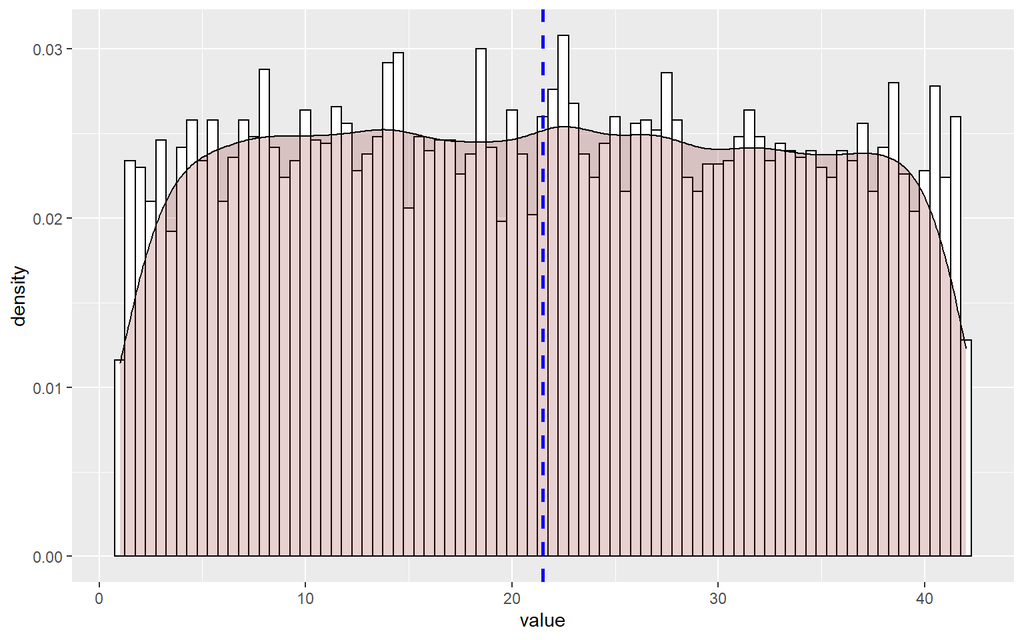

Well, maybe not so nice.

### Generating Y

Let’s generate the Normal variable Y and visualize it as well.

```r
avg <- (N+1)/2

Y <- rnorm(10000, mean= avg, sd=avg)
```

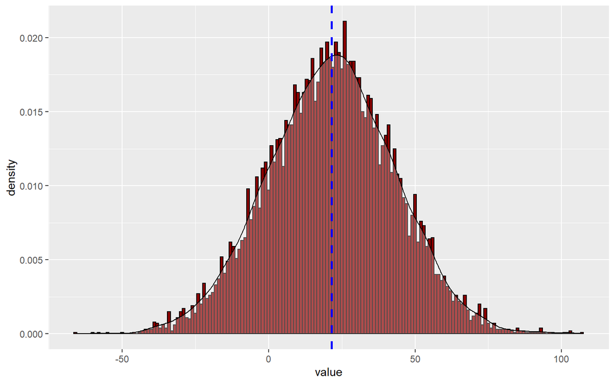

A little better. We can also take a look at this **normal distribution** as a boxplot:

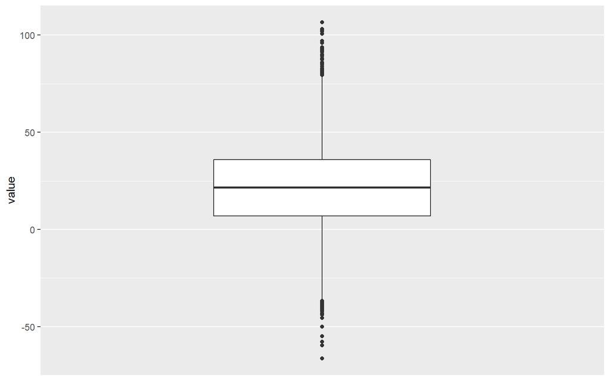

```r
# A basic box with the conditions colored
ggplot(dat_y, aes(y=value, fill=value)) + geom_boxplot() + scale_x_discrete()
```

## Probability.

Calculate as a minimum the below probabilities a through c. Assume the small letter “x” is estimated as the median of the X variable, and the small letter “y” is estimated as the 1st quartile of the Y variable. Interpret the meaning of all probabilities.

```r
x <- median(X)
y <- quantile(Y, probs = .25, names= FALSE)
```

### a. P(X>x | X>y)

We need to calculate the probability that the value of X is greater than the median when it is greater than the 1st quantile of the normal distribution. In other words
$$P(X>x|X>y) = \frac{P(X>x and X>y)}{P(X>y)}$$

```r
#let condition = X[X>y]
#Values in X where X > y
condition <- X[X>y]

#both_conditions: cases where both conditions are true
both_conditions <- condition[condition>x]

prob_a <- length(both_conditions) / length(condition)
prob_a
```

```
## [1] 0.5789047
```

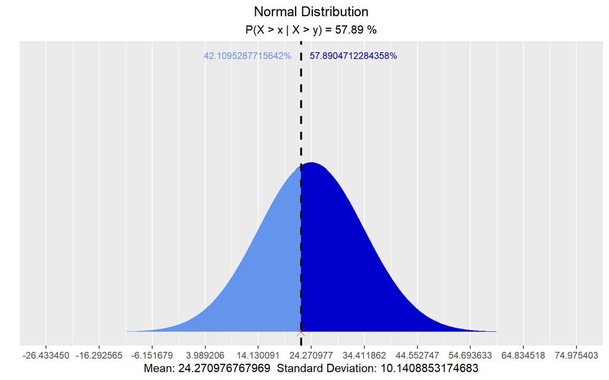

```r
library(vistributions) #allows us to visualize distributions.

p <- vdist_normal_perc(prob_a, mean(condition), sd(condition), 'upper', print_plot = FALSE)
#Change the subtitle so it makes sense
p$labels$subtitle=paste("P(X > x | X > y) =", round(100*prob_a, 2), "%")
p
```

There is a $57.89%$% Probability that X > than the median when X is greater than the first quantile of the normal distribution.

### b. P(X>x, Y>y)

We need to calculate the probability that a value of X is greater than the median **AND** that a value of Y is greater than the 1st quantile of the normal distribution.

$$P(X>x) = 50\% = 0.5$$

$$P(Y>y) = 75\% = 0.75$$

Therefore $P(X>x, Y>y) = P(X>x) * P(Y > y) = 0.5 * 0.75 = 37.5% $

```r
0.5 * 0.75
```

```
## [1] 0.375
```

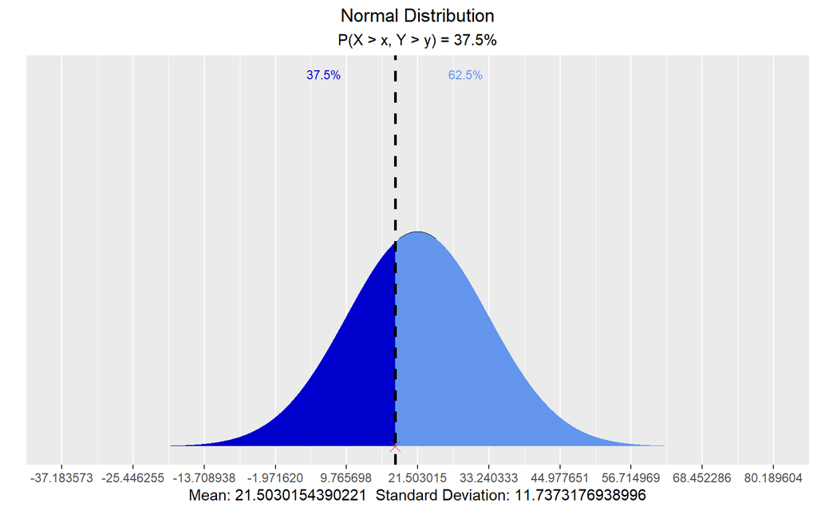

```r
p <- vdist_normal_perc(.375, mean = mean(X), sd = sd(X), print_plot = FALSE)
#Change the subtitle so it makes sense
p$labels$subtitle=paste("P(X > x, Y > y) = 37.5%")
p
```

### c. P(X<x | X>y)

We need to calculate the probability that the value of X is less than the median when it is greater than the 1st quantile of the normal distribution. In other words
$$P(X<x|X>y) = \frac{P(X<x and X>y)}{P(X>y)}$$

This should be equal to $1-P(X>x|X>y)$ which we calculated in *a*.

```r
#let condition = X[X>y]
#Values in X where X > y
# condition <- X[X>y]

#both_conditions: cases where both conditions are true
both_conditions2 <- condition[condition<x]

prob_c <- length(both_conditions2) / length(condition)
prob_c
```

```
## [1] 0.4210953
```

There is about $42.11%$% Probability that a value of X is less than the median when X is greater than the first quantile of the normal distribution. Which is the same as:

```r
1 - prob_a
```

```
## [1] 0.4210953
```

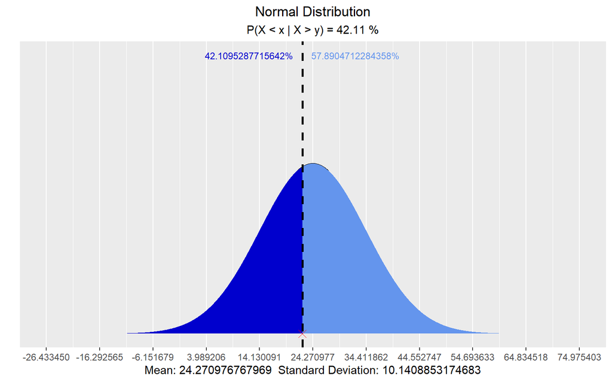

```r
p <- vdist_normal_perc(prob_c, mean(condition), sd(condition), 'lower', print_plot = FALSE)
#Change the subtitle so it makes sense
p$labels$subtitle=paste("P(X < x | X > y) =", round(100*prob_c, 2), "%")
p
```

## Investigate

Investigate whether P(X>x and Y>y)=P(X>x)P(Y>y) by building a table and evaluating the marginal and joint probabilities.

### P(X>x)

By definition the probability of a value of X being greater than its median is 50%.

```r
knitr::kable(prop.table(table(X>x)))
```

| Var1 | Freq |
| --- | --- |
| FALSE | 0.5 |
| TRUE | 0.5 |

### P(Y>y)

If y is the first quantile, the probability of a value of Y to be greater than y is 75%

```r
knitr::kable(prop.table(table(Y>y)))
```

| Var1 | Freq |
| --- | --- |
| FALSE | 0.25 |
| TRUE | 0.75 |

```r
totals_table <- table(X > x, Y > y)
colnames(totals_table) = c("Y < y", "Y > y")
rownames(totals_table)[rownames(totals_table) == FALSE] = "X < x"
rownames(totals_table)[rownames(totals_table) == TRUE] = "X > x"

knitr::kable(prop.table(totals_table))
```

|  | Y < y | Y > y |
| --- | --- | --- |
| X < x | 0.1253 | 0.3747 |
| X > x | 0.1247 | 0.3753 |

```r
(0.5 * 0.75)
```

```
## [1] 0.375
```

The result of the multiplication is $37.5\%$. I suspect the difference is due to rounding.

## Independence Test

Check to see if independence holds by using Fisher’s Exact Test and the Chi Square Test.

### Fisher’s Exact Test

$H_0=$ Variables are independent $H_1=$ Variables are dependent.

```r
fisher.test(totals_table)
```

```
##
##  Fisher's Exact Test for Count Data
##
## data:  totals_table
## p-value = 0.9081
## alternative hypothesis: true odds ratio is not equal to 1
## 95 percent confidence interval:
##  0.9183507 1.1029174
## sample estimates:
## odds ratio
##    1.00642
```

Because the p-value is greater than 0.05 we cannot reject the null hypothesis. The variables are independent.

### Chi Square Test.

$H_0=$ Variables are independent $H_1=$ Variables are dependent.

```r
chisq.test(totals_table)
```

```
##
##  Pearson's Chi-squared test with Yates' continuity correction
##
## data:  totals_table
## X-squared = 0.013333, df = 1, p-value = 0.9081
```

The p-value is greater than 0.05 so we do not reject the null hypothesis.

### What is the difference between the two? Which is most appropriate?

From the output from both tests we see that the p-value is greater than the significance level of 5%. Like any other statistical test, if the p-value is greater than the significance level, we cannot reject the null hypothesis. In our context, not rejecting the null hypothesis for the Fisher’s exact test of independence means that these two variables are independent.

Fisher’s exact test of independence is widely used when the sample sizes are small. In this case, I would recommend the Chi-Squared test.

### A picture is worth a thousand words:

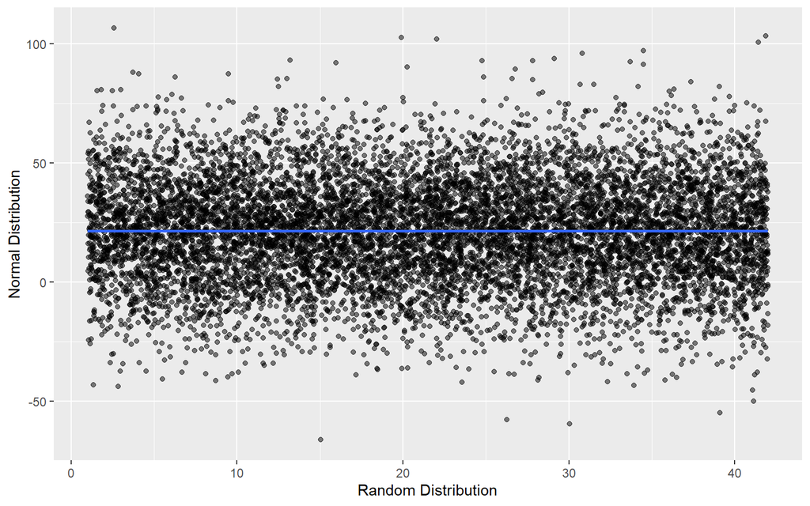

```r
my_data = data.frame('X'=X, 'Y'=Y)
my_data %>% ggplot(aes(x=X,y=Y)) +
  geom_point(alpha=0.5) +
  labs(x= "Random Distribution", y="Normal Distribution")+
  geom_smooth()
```

There appears to be no relation between these two variables.

# Problem II

You are to register for Kaggle.com (free) and compete in the House Prices: Advanced Regression Techniques competition. https://www.kaggle.com/c/house-prices-advanced-regression-techniques . I want you to do the following.

## Descriptive and Inferential Statistics.

Provide univariate descriptive statistics and appropriate plots for the training data set.

```r
# I really like the describe function
library(Hmisc)
train_df <- read_csv(here("data","train.csv"))

dim(train_df)
```

```
## [1] 1460   81
```

The Training Data Set has 1460 observations of the following 81 variables:

```r
head(describe(train_df, "Training Data Set"))
```

```
## Training Data Set
##
##  6  Variables      1460  Observations
## --------------------------------------------------------------------------------
## Id
##        n  missing distinct     Info     Mean      Gmd      .05      .10
##     1460        0     1460        1    730.5      487    73.95   146.90
##      .25      .50      .75      .90      .95
##   365.75   730.50  1095.25  1314.10  1387.05
##
## lowest :    1    2    3    4    5, highest: 1456 1457 1458 1459 1460
## --------------------------------------------------------------------------------
## MSSubClass
##        n  missing distinct     Info     Mean      Gmd      .05      .10
##     1460        0       15     0.94     56.9    43.19       20       20
##      .25      .50      .75      .90      .95
##       20       50       70      120      160
##
## lowest :  20  30  40  45  50, highest:  90 120 160 180 190
##
## Value         20    30    40    45    50    60    70    75    80    85    90
## Frequency    536    69     4    12   144   299    60    16    58    20    52
## Proportion 0.367 0.047 0.003 0.008 0.099 0.205 0.041 0.011 0.040 0.014 0.036
##
## Value        120   160   180   190
## Frequency     87    63    10    30
## Proportion 0.060 0.043 0.007 0.021
## --------------------------------------------------------------------------------
## MSZoning
##        n  missing distinct
##     1460        0        5
##
## lowest : C (all) FV      RH      RL      RM
## highest: C (all) FV      RH      RL      RM
##
## Value      C (all)      FV      RH      RL      RM
## Frequency       10      65      16    1151     218
## Proportion   0.007   0.045   0.011   0.788   0.149
## --------------------------------------------------------------------------------
## LotFrontage
```

[output cut: 8 more lines]

```
##        n  missing distinct     Info     Mean      Gmd      .05      .10
##     1460        0     1073        1    10517     5718     3312     5000
##      .25      .50      .75      .90      .95
##     7554     9478    11602    14382    17401
##
## lowest :   1300   1477   1491   1526   1533, highest:  70761 115149 159000 164660 215245
## --------------------------------------------------------------------------------
## Street
##        n  missing distinct
##     1460        0        2
##
## Value       Grvl  Pave
## Frequency      6  1454
## Proportion 0.004 0.996
## --------------------------------------------------------------------------------
```

```r
head(str(train_df))
```

```
## spec_tbl_df [1,460 x 81] (S3: spec_tbl_df/tbl_df/tbl/data.frame)
##  $ Id           : num [1:1460] 1 2 3 4 5 6 7 8 9 10 ...
##  $ MSSubClass   : num [1:1460] 60 20 60 70 60 50 20 60 50 190 ...
##  $ MSZoning     : chr [1:1460] "RL" "RL" "RL" "RL" ...
##  $ LotFrontage  : num [1:1460] 65 80 68 60 84 85 75 NA 51 50 ...
##  $ LotArea      : num [1:1460] 8450 9600 11250 9550 14260 ...
##  $ Street       : chr [1:1460] "Pave" "Pave" "Pave" "Pave" ...
##  $ Alley        : chr [1:1460] NA NA NA NA ...
##  $ LotShape     : chr [1:1460] "Reg" "Reg" "IR1" "IR1" ...
##  $ LandContour  : chr [1:1460] "Lvl" "Lvl" "Lvl" "Lvl" ...
##  $ Utilities    : chr [1:1460] "AllPub" "AllPub" "AllPub" "AllPub" ...
##  $ LotConfig    : chr [1:1460] "Inside" "FR2" "Inside" "Corner" ...
##  $ LandSlope    : chr [1:1460] "Gtl" "Gtl" "Gtl" "Gtl" ...
##  $ Neighborhood : chr [1:1460] "CollgCr" "Veenker" "CollgCr" "Crawfor" ...
##  $ Condition1   : chr [1:1460] "Norm" "Feedr" "Norm" "Norm" ...
##  $ Condition2   : chr [1:1460] "Norm" "Norm" "Norm" "Norm" ...
##  $ BldgType     : chr [1:1460] "1Fam" "1Fam" "1Fam" "1Fam" ...
##  $ HouseStyle   : chr [1:1460] "2Story" "1Story" "2Story" "2Story" ...
##  $ OverallQual  : num [1:1460] 7 6 7 7 8 5 8 7 7 5 ...
##  $ OverallCond  : num [1:1460] 5 8 5 5 5 5 5 6 5 6 ...
##  $ YearBuilt    : num [1:1460] 2003 1976 2001 1915 2000 ...
##  $ YearRemodAdd : num [1:1460] 2003 1976 2002 1970 2000 ...
##  $ RoofStyle    : chr [1:1460] "Gable" "Gable" "Gable" "Gable" ...
##  $ RoofMatl     : chr [1:1460] "CompShg" "CompShg" "CompShg" "CompShg" ...
##  $ Exterior1st  : chr [1:1460] "VinylSd" "MetalSd" "VinylSd" "Wd Sdng" ...
##  $ Exterior2nd  : chr [1:1460] "VinylSd" "MetalSd" "VinylSd" "Wd Shng" ...
##  $ MasVnrType   : chr [1:1460] "BrkFace" "None" "BrkFace" "None" ...
##  $ MasVnrArea   : num [1:1460] 196 0 162 0 350 0 186 240 0 0 ...
##  $ ExterQual    : chr [1:1460] "Gd" "TA" "Gd" "TA" ...
##  $ ExterCond    : chr [1:1460] "TA" "TA" "TA" "TA" ...
##  $ Foundation   : chr [1:1460] "PConc" "CBlock" "PConc" "BrkTil" ...
##  $ BsmtQual     : chr [1:1460] "Gd" "Gd" "Gd" "TA" ...
##  $ BsmtCond     : chr [1:1460] "TA" "TA" "TA" "Gd" ...
##  $ BsmtExposure : chr [1:1460] "No" "Gd" "Mn" "No" ...
##  $ BsmtFinType1 : chr [1:1460] "GLQ" "ALQ" "GLQ" "ALQ" ...
##  $ BsmtFinSF1   : num [1:1460] 706 978 486 216 655 ...
##  $ BsmtFinType2 : chr [1:1460] "Unf" "Unf" "Unf" "Unf" ...
##  $ BsmtFinSF2   : num [1:1460] 0 0 0 0 0 0 0 32 0 0 ...
##  $ BsmtUnfSF    : num [1:1460] 150 284 434 540 490 64 317 216 952 140 ...
##  $ TotalBsmtSF  : num [1:1460] 856 1262 920 756 1145 ...
```

[output cut: 111 more lines]

```
##   ..   OpenPorchSF = col_double(),
##   ..   EnclosedPorch = col_double(),
##   ..   `3SsnPorch` = col_double(),
##   ..   ScreenPorch = col_double(),
##   ..   PoolArea = col_double(),
##   ..   PoolQC = col_character(),
##   ..   Fence = col_character(),
##   ..   MiscFeature = col_character(),
##   ..   MiscVal = col_double(),
##   ..   MoSold = col_double(),
##   ..   YrSold = col_double(),
##   ..   SaleType = col_character(),
##   ..   SaleCondition = col_character(),
##   ..   SalePrice = col_double()
##   .. )
```

### Scatterplot

Provide a scatterplot matrix for at least two of the independent variables and the dependent variable.

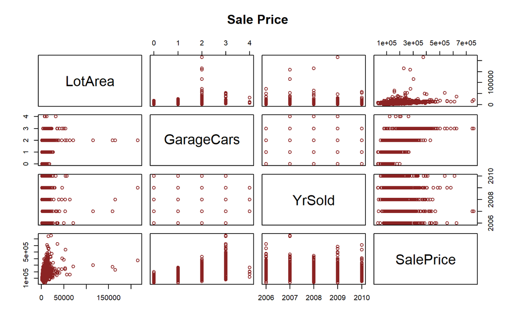

```r
pairs(~ LotArea + GarageCars + YrSold + SalePrice, data = train_df, main = "Sale Price", col="brown4")
```

### Correlation Matrix

Derive a correlation matrix for any three quantitative variables in the dataset.

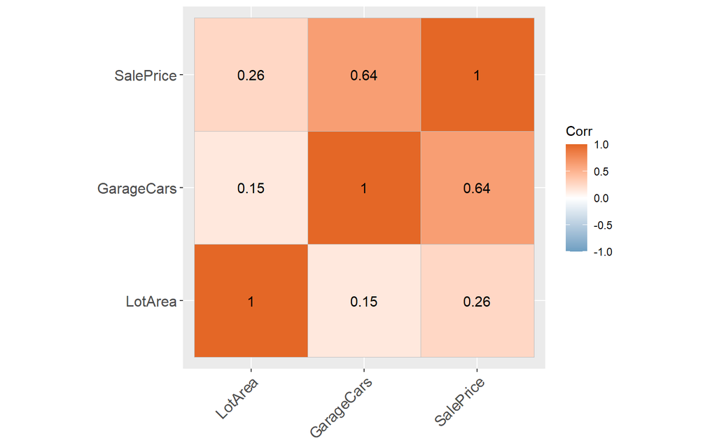

```r
#To plot the correlation
library(ggcorrplot)

#get the correlation
train_cor <- train_df %>%
  select( LotArea, GarageCars, SalePrice) %>%
  cor()

#get the p.mat
p.mat <- train_df %>%
  select( LotArea, GarageCars, SalePrice) %>%
    cor_pmat()

ggcorrplot(train_cor,
           ggtheme = ggplot2::theme_gray,
           lab = TRUE,
           p.mat = p.mat,
           colors = c("#6D9EC1", "white", "#E46726"))
```

### Hypothesis test

Test the hypotheses that the correlations between each pairwise set of variables is 0 and provide an 80% confidence interval.

**LotArea vs SalePrice**

$H_0$: Correlation between variables is zero $H_1$: Correlation is not zero

```r
cor.test(train_df$LotArea, train_df$SalePrice, method = 'pearson', conf.level = 0.8)
```

```
##
##  Pearson's product-moment correlation
##
## data:  train_df$LotArea and train_df$SalePrice
## t = 10.445, df = 1458, p-value < 2.2e-16
## alternative hypothesis: true correlation is not equal to 0
## 80 percent confidence interval:
##  0.2323391 0.2947946
## sample estimates:
##       cor
## 0.2638434
```

**GarageCars vs SalePrice**

$H_0$: Correlation between variables is zero $H_1$: Correlation is not zero

```r
cor.test(train_df$GarageCars, train_df$SalePrice, method = 'pearson', conf.level = 0.8)
```

```
##
##  Pearson's product-moment correlation
##
## data:  train_df$GarageCars and train_df$SalePrice
## t = 31.839, df = 1458, p-value < 2.2e-16
## alternative hypothesis: true correlation is not equal to 0
## 80 percent confidence interval:
##  0.6201771 0.6597899
## sample estimates:
##       cor
## 0.6404092
```

**Discuss the meaning of your analysis.** Both p-values are very close to 0 for each of the variables tested: LotArea and GarageCars. Because neither p-value is greater than 0.05, being essentially zero, we reject both null hypotheses and must accept the alternate hypothesis that **True correlation is not equal to 0**

**Would you be worried about familywise error? Why or why not?** No. The p-values are too low for us to worry about False discoveries or Type I errors.

## Linear Algebra and Correlation.

Let’s perform some operations on the correlation Matrix we obtained earlier.

### Invert

Invert your correlation matrix from above. (This is known as the precision matrix and contains variance inflation factors on the diagonal.)

**Correlation Matrix**

```r
train_cor %>% round()
```

```
##            LotArea GarageCars SalePrice
## LotArea          1          0         0
## GarageCars       0          1         1
## SalePrice        0          1         1
```

**Inverted Matrix**

```r
library(matlib)
precision_matrix <- solve(train_cor)  #Could also use matlib::Ginv but loses the labels
precision_matrix %>% round()
```

```
##            LotArea GarageCars SalePrice
## LotArea          1          0         0
## GarageCars       0          2        -1
## SalePrice        0         -1         2
```

### Multiply

Multiply the correlation matrix by the precision matrix, and then multiply the precision matrix by the correlation matrix.

**Correlation Matrix * Precision Matrix**

```r
product_matrix <- train_cor %*% precision_matrix
product_matrix %>% round()
```

```
##            LotArea GarageCars SalePrice
## LotArea          1          0         0
## GarageCars       0          1         0
## SalePrice        0          0         1
```

**Precision * Correlation**

```r
product_matrix_2 <- precision_matrix %*% train_cor
product_matrix_2 %>% round()
```

```
##            LotArea GarageCars SalePrice
## LotArea          1          0         0
## GarageCars       0          1         0
## SalePrice        0          0         1
```

### LU Decomposition

Conduct LU decomposition on the matrix.

```r
lu <- LU(train_cor)
lu
```

```
## $P
##      [,1] [,2] [,3]
## [1,]    1    0    0
## [2,]    0    1    0
## [3,]    0    0    1
##
## $L
##           [,1]      [,2] [,3]
## [1,] 1.0000000 0.0000000    0
## [2,] 0.1548707 1.0000000    0
## [3,] 0.2638433 0.6142811    1
##
## $U
##      LotArea GarageCars SalePrice
## [1,]       1  0.1548707 0.2638433
## [2,]       0  0.9760150 0.5995476
## [3,]       0  0.0000000 0.5620960
```

**Verify**

```r
with(lu, L %*% U) #check that A = L * U
```

```
##        LotArea GarageCars SalePrice
## [1,] 1.0000000  0.1548707 0.2638433
## [2,] 0.1548707  1.0000000 0.6404092
## [3,] 0.2638433  0.6404092 1.0000000
```

## Calculus-Based Probability & Statistics.

Many times, it makes sense to fit a closed form distribution to data. Select a variable in the Kaggle.com training dataset that is skewed to the right, shift it so that the minimum value is absolutely above zero if necessary.

```r
min(train_df$SalePrice)
```

```
## [1] 34900
```

Let’s take a look at the histogram:

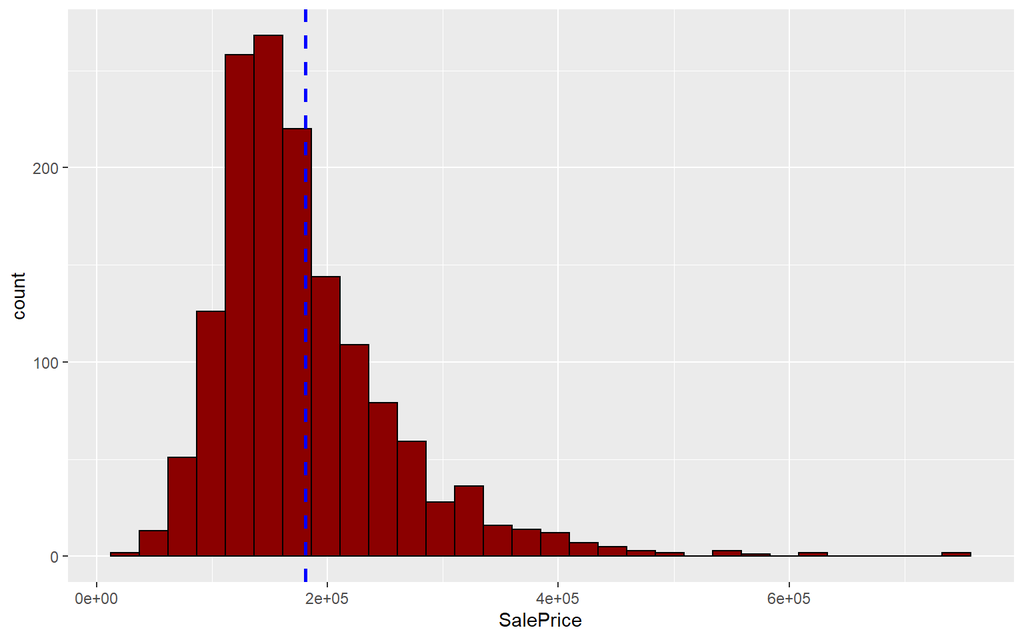

```r
train_df %>% ggplot(aes(SalePrice)) +
    geom_histogram(colour="black", fill="darkred")+
    geom_vline(aes(xintercept=mean(SalePrice, na.rm=T)),   # Ignore NA values for mean
        color="blue", linetype="dashed", size=1)
```

It is skewed to the right.

**Shift it if necessary**

```r
shifted_train <- train_df %>%
    mutate(SalePrice = SalePrice - 34900)

min(shifted_train$SalePrice)
```

```
## [1] 0
```

Then load the MASS package and run fitdistr to fit an exponential probability density function. (See https://stat.ethz.ch/R-manual/R-devel/library/MASS/html/fitdistr.html ).

```r
library(MASS)
fit_saleprice <- fitdistr(shifted_train$SalePrice,
                             densfun = "exponential")
fit_saleprice
```

```
##        rate
##   6.848321e-06
##  (1.792287e-07)
```

**Optimal Value of $\lambda$** Find the optimal value of $\lambda$ for this distribution, and then take 1000 samples from this exponential distribution using this value (e.g., rexp(1000, $\lambda$)).

`fitdistr` returns an object, `fit_saleprice` in this case, which contains an `estimate` value that is the optimal value for this distribution.

```r
fit_sample <- rexp(1000, fit_saleprice$estimate)
```

**Plot a histogram and compare it with a histogram of your original variable.**

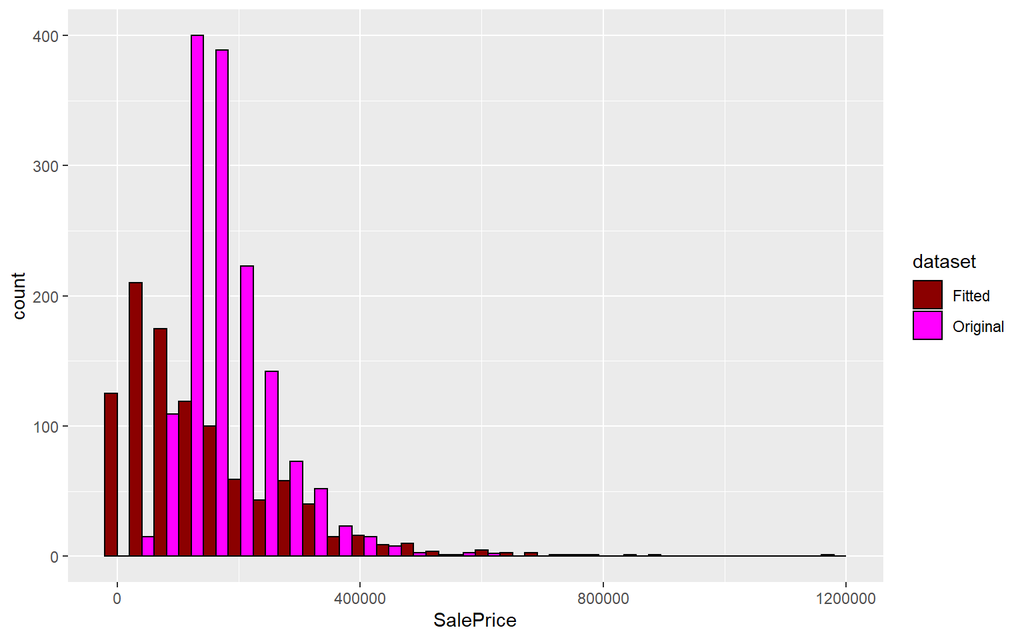

```r
DF <- rbind(data.frame(dataset="Fitted", SalePrice=fit_sample),
            data.frame(dataset="Original", SalePrice=train_df$SalePrice))
DF$dataset <- as.factor(DF$dataset)

ggplot(DF, aes(x=SalePrice, fill=dataset)) +
  geom_histogram( colour="black", position="dodge") +
  scale_fill_manual( values=c("darkred","magenta"))
```

**Using the exponential pdf, find the 5th and 95th percentiles using the cumulative distribution function (CDF).**

```r
quantile(fit_sample, c(0.05, 0.95))
```

```
##         5%        95%
##   6471.737 403075.648
```

**Also generate a 95% confidence interval from the empirical data, assuming normality.**

```r
res <- t.test(fit_sample)
res$conf.int
```

```
## [1] 132990.7 149982.4
## attr(,"conf.level")
## [1] 0.95
```

Finally, provide the empirical 5th percentile and 95th percentile of the data.

```r
quantile(train_df$SalePrice, c(.05, .95))
```

```
##     5%    95%
##  88000 326100
```

```r
res2 <- t.test(train_df$SalePrice)
res2$conf.int
```

```
## [1] 176842.8 184999.6
## attr(,"conf.level")
## [1] 0.95
```

## Modeling.

Build some type of multiple regression model and submit your model to the competition board. Provide your complete model summary and results with analysis. Report your Kaggle.com user name and score.

### Linear Regression Model

```r
model <- lm(log(SalePrice) ~ GarageCars + LotArea + YrSold + Neighborhood + BldgType + YearBuilt, data = train_df)
summary(model)
```

```
##
## Call:
## lm(formula = log(SalePrice) ~ GarageCars + LotArea + YrSold +
##     Neighborhood + BldgType + YearBuilt, data = train_df)
##
## Residuals:
##      Min       1Q   Median       3Q      Max
## -1.06636 -0.11936 -0.00628  0.12064  1.12879
##
## Coefficients:
##                       Estimate Std. Error t value Pr(>|t|)
## (Intercept)          9.983e+00  8.866e+00   1.126 0.260366
## GarageCars           1.712e-01  1.030e-02  16.629  < 2e-16 ***
## LotArea              4.854e-06  6.559e-07   7.400 2.31e-13 ***
## YrSold              -2.689e-03  4.390e-03  -0.613 0.540220
## NeighborhoodBlueste -1.424e-01  1.666e-01  -0.855 0.392898
## NeighborhoodBrDale  -2.303e-01  8.492e-02  -2.712 0.006777 **
## NeighborhoodBrkSide -2.100e-01  7.183e-02  -2.923 0.003517 **
## NeighborhoodClearCr  7.986e-03  7.508e-02   0.106 0.915307
## NeighborhoodCollgCr -1.112e-01  6.150e-02  -1.809 0.070672 .
## NeighborhoodCrawfor  1.963e-01  7.035e-02   2.790 0.005340 **
## NeighborhoodEdwards -2.552e-01  6.584e-02  -3.876 0.000111 ***
## NeighborhoodGilbert -1.514e-01  6.450e-02  -2.347 0.019041 *
## NeighborhoodIDOTRR  -3.995e-01  7.575e-02  -5.274 1.54e-07 ***
## NeighborhoodMeadowV -2.850e-01  7.960e-02  -3.580 0.000355 ***
## NeighborhoodMitchel -2.272e-01  6.726e-02  -3.378 0.000749 ***
## NeighborhoodNAmes   -1.859e-01  6.337e-02  -2.933 0.003412 **
## NeighborhoodNoRidge  2.680e-01  6.863e-02   3.905 9.88e-05 ***
## NeighborhoodNPkVill -1.054e-01  9.293e-02  -1.135 0.256765
## NeighborhoodNridgHt  2.429e-01  6.234e-02   3.897 0.000102 ***
## NeighborhoodNWAmes  -8.304e-02  6.539e-02  -1.270 0.204356
## NeighborhoodOldTown -1.970e-01  7.015e-02  -2.808 0.005047 **
## NeighborhoodSawyer  -2.484e-01  6.662e-02  -3.729 0.000200 ***
## NeighborhoodSawyerW -1.155e-01  6.514e-02  -1.773 0.076442 .
## NeighborhoodSomerst  1.065e-02  6.165e-02   0.173 0.862867
## NeighborhoodStoneBr  3.130e-01  7.053e-02   4.438 9.77e-06 ***
## NeighborhoodSWISU    5.656e-04  8.022e-02   0.007 0.994375
## NeighborhoodTimber  -3.479e-02  6.993e-02  -0.498 0.618872
## NeighborhoodVeenker  1.187e-01  8.774e-02   1.353 0.176230
## BldgType2fmCon      -2.417e-02  4.176e-02  -0.579 0.562894
## BldgTypeDuplex      -1.478e-01  3.206e-02  -4.612 4.35e-06 ***
## BldgTypeTwnhs       -2.364e-01  4.427e-02  -5.340 1.08e-07 ***
## BldgTypeTwnhsE      -1.857e-01  2.774e-02  -6.694 3.12e-11 ***
## YearBuilt            3.661e-03  4.285e-04   8.542  < 2e-16 ***
## ---
## Signif. codes:  0 '***' 0.001 '**' 0.01 '*' 0.05 '.' 0.1 ' ' 1
##
## Residual standard error: 0.2205 on 1427 degrees of freedom
## Multiple R-squared:  0.702,  Adjusted R-squared:  0.6953
## F-statistic: 105.1 on 32 and 1427 DF,  p-value: < 2.2e-16
```

This model gives us an $R^2$ of 0.702 which means it accounts for 70% of the value of SalePrice. We could potentially adjust it a little more.

**Testing the Model**

```r
predicted_df <- read.csv(here("data","test.csv"))

predicted_df$SalePrice <- predict(model, predicted_df)

submission <- predicted_df %>%
    dplyr::select(Id, SalePrice) %>%
    mutate( SalePrice = ifelse(is.na(SalePrice), 0, SalePrice))

write.csv(submission, here("data","GC-Submission.csv"), row.names=FALSE)
```

### Kaggle Submission Score Info

Kaggle UserName: George Cruz Deschamps Initial Score: 9.46108

### Scaling the numerical features

```r
library(caret)
numerical_variables <- c( 'LotArea',
                          'LotFrontage',
                          'TotalBsmtSF')
pre_proc_val <- preProcess(train_df[,numerical_variables],
                           method = c("center", "scale"))

train_df_scaled <- train_df
train_df_scaled[,numerical_variables] <- predict(pre_proc_val,
                                                 train_df[,numerical_variables])

model2 <- lm(log(SalePrice) ~ GarageCars +
                 LotArea +
                 LotFrontage +
                 TotalBsmtSF +
                 YrSold +
                 Neighborhood +
                 BldgType +
                 YearBuilt, data = train_df_scaled)
summary(model2)
```

```
##
## Call:
## lm(formula = log(SalePrice) ~ GarageCars + LotArea + LotFrontage +
##     TotalBsmtSF + YrSold + Neighborhood + BldgType + YearBuilt,
##     data = train_df_scaled)
##
## Residuals:
##      Min       1Q   Median       3Q      Max
## -1.44451 -0.10294  0.00542  0.10989  1.07764
##
## Coefficients:
##                      Estimate Std. Error t value Pr(>|t|)
## (Intercept)         13.826645   9.395055   1.472 0.141373
## GarageCars           0.142941   0.010804  13.230  < 2e-16 ***
## LotArea              0.037888   0.009144   4.144 3.67e-05 ***
## LotFrontage          0.012885   0.008396   1.535 0.125166
## TotalBsmtSF          0.094287   0.007857  12.001  < 2e-16 ***
## YrSold              -0.003370   0.004656  -0.724 0.469232
## NeighborhoodBlueste -0.012287   0.161970  -0.076 0.939541
## NeighborhoodBrDale  -0.128129   0.086057  -1.489 0.136787
## NeighborhoodBrkSide -0.125161   0.075249  -1.663 0.096523 .
## NeighborhoodClearCr  0.096681   0.087922   1.100 0.271723
## NeighborhoodCollgCr -0.016198   0.065550  -0.247 0.804872
## NeighborhoodCrawfor  0.238596   0.074407   3.207 0.001379 **
## NeighborhoodEdwards -0.173894   0.068977  -2.521 0.011833 *
## NeighborhoodGilbert -0.007841   0.070456  -0.111 0.911411
## NeighborhoodIDOTRR  -0.347053   0.078657  -4.412 1.12e-05 ***
## NeighborhoodMeadowV -0.204131   0.083388  -2.448 0.014513 *
## NeighborhoodMitchel -0.148175   0.072339  -2.048 0.040750 *
## NeighborhoodNAmes   -0.113216   0.066843  -1.694 0.090579 .
## NeighborhoodNoRidge  0.315668   0.072721   4.341 1.54e-05 ***
## NeighborhoodNPkVill -0.018050   0.100623  -0.179 0.857665
## NeighborhoodNridgHt  0.260041   0.065060   3.997 6.82e-05 ***
## NeighborhoodNWAmes  -0.031471   0.070800  -0.445 0.656756
## NeighborhoodOldTown -0.129057   0.073127  -1.765 0.077855 .
## NeighborhoodSawyer  -0.166868   0.071749  -2.326 0.020205 *
## NeighborhoodSawyerW -0.007548   0.068599  -0.110 0.912401
## NeighborhoodSomerst  0.116123   0.064894   1.789 0.073805 .
## NeighborhoodStoneBr  0.363981   0.075483   4.822 1.61e-06 ***
## NeighborhoodSWISU    0.041902   0.082843   0.506 0.613089
## NeighborhoodTimber   0.054124   0.074251   0.729 0.466190
## NeighborhoodVeenker  0.243273   0.099741   2.439 0.014875 *
## BldgType2fmCon      -0.006448   0.042033  -0.153 0.878109
## BldgTypeDuplex      -0.113373   0.032738  -3.463 0.000553 ***
## BldgTypeTwnhs       -0.142714   0.047802  -2.986 0.002890 **
## BldgTypeTwnhsE      -0.112739   0.031309  -3.601 0.000331 ***
## YearBuilt            0.002410   0.000447   5.391 8.46e-08 ***
## ---
## Signif. codes:  0 '***' 0.001 '**' 0.01 '*' 0.05 '.' 0.1 ' ' 1
##
## Residual standard error: 0.2115 on 1166 degrees of freedom
##   (259 observations deleted due to missingness)
## Multiple R-squared:  0.7488, Adjusted R-squared:  0.7415
## F-statistic: 102.3 on 34 and 1166 DF,  p-value: < 2.2e-16
```

This is a little better @ 75% $R^2$

Let’s see how it fares in the competition.

```r
predicted_df2 <- read.csv(here("data","test.csv"))

predicted_df2$SalePrice <- predict(model2, predicted_df2)

submission2 <- predicted_df2 %>%
    dplyr::select(Id, SalePrice) %>%
    mutate( SalePrice = ifelse(is.na(SalePrice), 0, SalePrice))

write.csv(submission2, here("data","GC-Submission2.csv"), row.names=FALSE)
```

### 2nd Kaggle Submission Score Info

Kaggle UserName: George Cruz Deschamps Initial Score: 7.2548

### Conclusion

Adding those variables and scaling them improved the model a little. I would like to try other regression models like:

- Ridge Regression
- LASSO Regression and
- Elastic Net

I did try them on my project to no avail. Need a little more research before I am able to pull those off.